# Cyclistic Bike-Share Case Study (R Version)

Elnur

2025-12-18

```r
library(tidyverse)
library(dplyr)
library(lubridate)
```

# 1. Business Task (Ask)

**Business question:**  
How do annual members and casual riders use Cyclistic bikes differently?

**Objective:**  
Identify behavioral differences to support marketing strategies aimed at converting casual riders into annual members.

**Stakeholders:**  
- Director of Marketing  
- Marketing Analytics Team  
- Cyclistic Executive Team

# 2. Data (Prepare)

I used publicly available Divvy bike-share trip data from 2019 Q1–Q4. Click here [link](https://divvy-tripdata.s3.amazonaws.com/index.html)

**Data characteristics:**

- Anonymized trip-level data
- No personally identifiable information (PII)
- Contains system tests and outliers that require cleaning

# 3. Data Processing (Process)

**Data cleaning steps performed in R:**

- Standardized column names across files
- Combined quarterly datasets into full-year 2019
- Converted trip duration from seconds to minutes
- Removed invalid rides (duration < 1 minute or > 1440 minutes)
- Created time-based features (weekday, month, hour)

# 4. Analysis (Analyze)

This section summarizes the key behavioral differences between Customer (casual riders) and Subscriber (annual members).

### 4.1 Key metrics by rider type

```
## # A tibble: 2 × 3
##   User_Type    Rides Avg_Duration
##   <chr>        <dbl>        <dbl>
## 1 Customer    879290         39.4
## 2 Subscriber 2936866         12.9
```

### 4.2 Main findings

- **Casual riders** have longer ride durations on average (likely leisure use).
- **Members** have shorter ride durations and significantly more rides (likely commuting / frequent utility trips).

# 5. Visualizations (Share)

Below are the supporting charts created in R and saved to the Outputs folder.

### 5.1 Ride duration

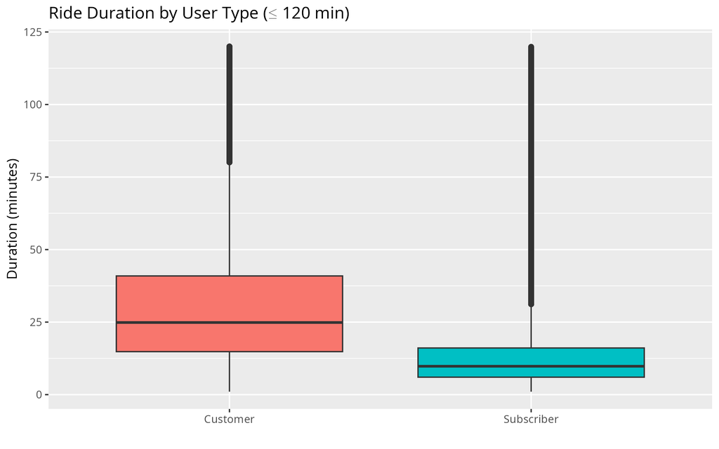

### 5.2 Rides by weekday

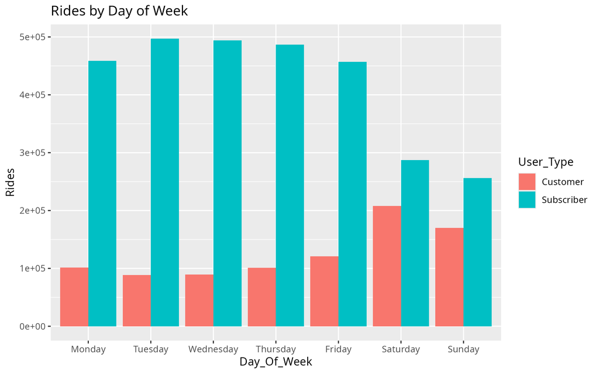

### 5.3 Rides by hour

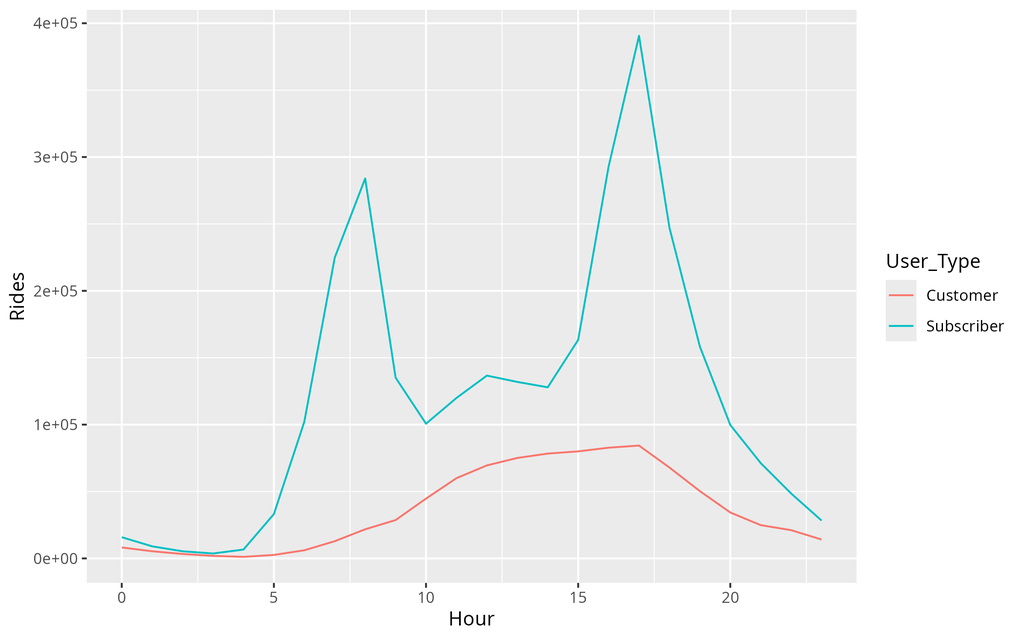

### 5.4 Rides by month

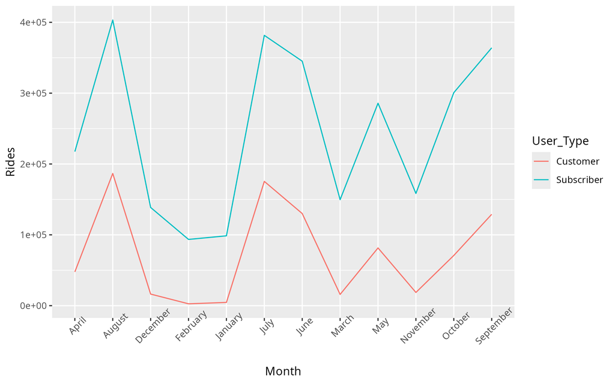

# 6. Recommendations (Act)

**Based on the analysis:**

1. **Weekend conversion campaigns:** Target casual riders on weekends with membership promotions emphasizing savings after multiple rides.
2. **Station-based targeting:** Focus digital ads and on-site messaging at stations with the highest casual usage.
3. **Commute messaging for frequent riders:** Promote membership benefits for riders who show repeated weekday usage patterns (e.g., morning/evening peaks).